# Runit

Система инициализации runit

Добрынин Никита Артёмович

1132255598@rudn.ru

Российский университет дружбы народов

2026-04-26

# Информация

## Докладчик

- Добрынин Никита Артёмович
- Студент направления “Бизнес-информатика”
- Группа НБИбд-d01-25
- Российский университет дружбы народов им. П. Лумумбы
- 1132255598@rudn.ru
- https://github.com/DobryninNik

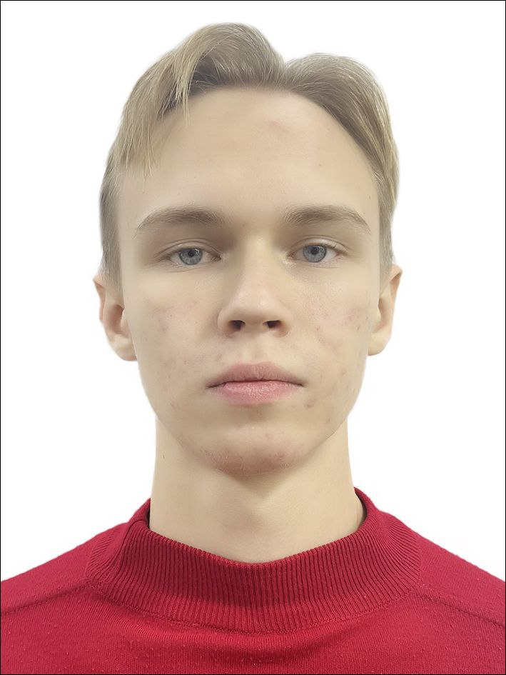

# Вводная часть

## Актуальность

- Рост популярности контейнеризации (Docker, Podman, LXC) требует лёгких init-систем
- В сообществе сохраняется запрос на простые и прозрачные инструменты
- Systemd не всегда удобен для встраиваемых систем и слабого железа (Raspberry Pi, роутеры)
- Runit остаёся работающей альтернативой, но о нём мало систематизированной информации на русском языке

## Объект и предмет исследования

Система инициализации Runit как процесс с PID 1 и инструмент управления сервисами.

## Цели и задачи

- Проанализировать архитектуру, принципы работы и сценарии применения Runit, выявить его сильные и слабые стороны по сравнению с другими init-системами.
- Задачи:
1. Изучить историю появления и философию Runit.
2. Описать трёхстадийную модель загрузки и механизм управления сервисами.
3. Привести практический пример конфигурации сервиса.
4. Выделить основные преимущества и ограничения.
5. Определить области, где использование Runit наиболее оправдано.

## Материалы и методы

Материалы исследования: Официальная документация, Открытые источники информации

Методы исследования: Анализ литературы и документации, Описательный метод, Сравнительный анализ, Исторический метод

# Основная часть

## Исторический контекст

Почему появился runit?

1. SysVinit – медленный и последовательный
2. Systemd – быстрый, но тяжёлый и нарушает Unix-way
3. 2004 год – Геррит Пэйп создаёт Runit как альтернативу: простота, скорость, надёжность

## Unix-way и KISS

Модульность runit позволяет заменять любой компонент.

runit легкопортируемый - работает на linux, BSD, и даже macOS.

Не занимаеться сетью, логированием или таймерами - только PID 1 и супервизор

## Трёхстадийная модель

[output not shown]

## Управление сервисами

В Runit управление сервисами радикально отличается от привычных systemctl или скриптов init.d.

Каждый сервис — это просто директория с файлом run (исполняемым скриптом или бинарным файлом)

Нет централизованных файлов .service с синтаксисом INI или XML. Настройка — это shell-скриптинг.

## Как включить/выключить сервис?

Управление происходит через создание или удаление символических ссылок в директории /etc/service

Пример базового сервиса (/etc/sv/myapp/run):

#!/bin/sh

exec my_app_daemon >> /var/log/myapp.log 2>&1

Запуск сервиса осуществляется командой ln -s /etc/sv/myapp /etc/service/.

## Преймущества и недосатки

В табл. 1 приведены основные преймущества и недостатки runit.

Таблица 1: Преймущества и недостатки

| Преймущества | Недостатки |
| --- | --- |
| Истинная простота | Ручная работа |
| Скорость и ресурсы | Меньшая функциональность |
| Надёжный супервизор | Сообщество |

## Применение

Runit является стандартной системой инициализации для следующих дистрибутивов:

1. Void Linux: Самый известный представитель. Выбор Runit обусловлен желанием оставаться простым и прозрачным.
2. AntiX: Легковесный дистрибутив для старого оборудования. Runit там используется для ускорения загрузки
3. Dragora GNU/Linux-Libre: Дистрибутив, полностью свободный от проприетарных компонентов

## Выводы

runit - это пример следования принципу KISS (Keep It Simple, Stupid). Сейчас программное обеспеченик становится всё более монолитным, в то время как runit - это прозрачность и модульность. Однако, за простоту приходится платить удобством автоматизации. Runit идеально подходит для контейнеров, встраиваемых систем и минималистичных серверов, где каждый мегабайт памяти на счету и нет необходимости в сложной логике зависимостей. Но runit не подходит для систем с жесткими зависимостями.